# OpenCaseStudies - Identifying factors related to hypertension using NHANES data

OpenCaseStudies Team

# Motivation

Hypertension is one of the most common diseases in the world. It has been associated with myocardial infarction, stroke, renal failure, and death if not detected early and treated appropriately. According to the Center for Disease Control’s [Behavioral Risk Factor Surveillance System (BRFSS)](https://www.cdc.gov/brfss/), around 75 million American adults (32%) are estimated to have high blood pressure, costing the US around $48.6 billion each year. This total includes the cost of healthcare services, medications to treat high blood pressure, and missed days of work.

In this case study, we will explore the relationship between hypertension and a variety of risk factors.

This case study introduces survey methods for logistic regression and compares the results from survey-weighted logistic regression to standard logistic regression. The plot below visualizes the comparison between these two methods; it shows the estimated coefficients (with standard error) from each method for the risk factors under consideration. Note that both the estimates and their standard errors are different when using ([logistic regression](https://en.wikipedia.org/wiki/Logistic_regression) and [survey-weighted logistic regression](http://citeseerx.ist.psu.edu/viewdoc/download;jsessionid=9591E971AF4061BBF8F98083422FF313?doi=10.1.1.151.6423&rep=rep1&type=pdf)). We will discuss later which model is a better choice for this analysis.

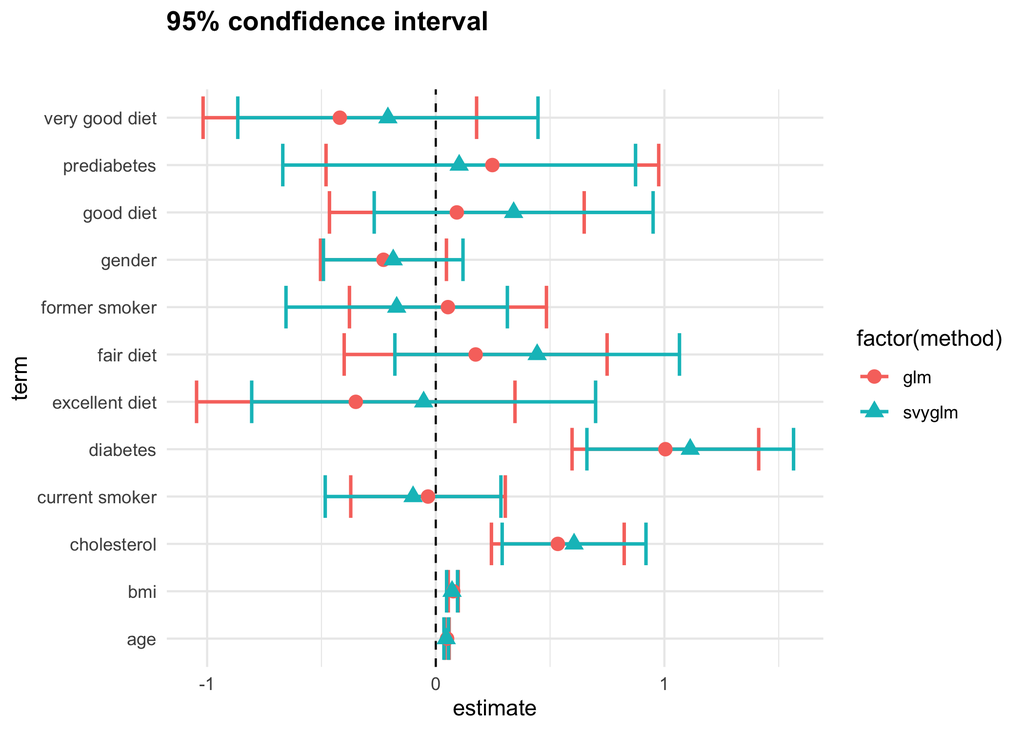

The libraries used in this study are listed in the following table, along with their purpose in this particular case study:

| Library | Purpose |
| --- | --- |
| `tidyverse` | A coherent system of packages for data manipulation, exploration and visualization |
| `haven` | A useful tool to import and export data from SAS, STATA, and SPSS formats |
| `broom` | Takes the messy output of built-in functions in R, such as lm, nls, or t.test, and turns it into tidy data frames |
| `survey` | Provides useful functions for analyzing complex survey samples |
| `ggpubr` | Provides some easy-to-use functions for creating and customizing ‘ggplot2’- based publication ready plots |
| `ggrepel` | Provides text and label geoms for ‘ggplot2’ that help to avoid overlapping text labels |
| `kableExtra` | Helps with building common complex tables and manipulating table styles; creates awesome HTML tables |
| `plotrix` | A variety of plots, various labeling, axis and color scaling functions |
| `knitr` | — |

In order to run the code for this case study, please ensure you have these packages installed.

The learning objectives for this case study include:

- data visualization
- logistic regression
- survey-weighted analysis
- selection of survey weights for unbalanced data

# What is the data?

For this case study, we will use data from the [New York City (NYC) Health and Nutrition Examination Survey (NYC HANES)](http://nychanes.org/), modeled on the [National Health and Nutrition Examination Survey (NHANES)](https://wwwn.cdc.gov/nchs/nhanes/default.aspx). NHANES is a population-based, cross-sectional study with data collected from a physical examination and laboratory tests, as well as a face-to-face interview and an audio computer-assisted self-interview (ACASI). It is designed to assess the health and nutritional status of adults and children in the United States. NYC HANES is a local version of NHANES, which implies it mainly focuses on New York area.

To access the NYC HANES data, go to the [NYC HANES data page](http://nychanes.org/data/) and click the **NYC HANES Analytics Datasets** link; it will download automatically. (A static link to this datafile can be found [here](http://nychanes.org/wp-content/uploads/sites/6/2019/01/public_v3_122018.sas7bdat).)

The data we will be using in this case study was collected from August 2013 to June 2014 and is called the **NYC HANES 2013-14 Blood Pressure Data**. The survey used a probability sample of non-institutionalized adult New York City residents (ages 20 years or older) to provide representative citywide estimates. For further details, please refer to the [NYC HANES website](http://nychanes.org/).

In addition to the datafile, there are other useful resources available on the website including:

- [Data Documents](http://nychanes.org/wp-content/uploads/sites/6/2019/01/28283961_Data-Documentation.pdf): Provides information on how best to analyze the NYC HANES 2013-14 dataset, given its population-based and clustered sampling scheme.
- [Analytics Guideline](http://nychanes.org/wp-content/uploads/sites/6/2015/11/ANALYTIC-GUIDELINES-2016_V2.pdf): Provides overall guidance on the use of the NYC HANES 2013-14 dataset and statistical weights, as well as other analytic issues pertaining to assessing statistical reliability of estimates.
- [Variable Codebook](http://nychanes.org/wp-content/uploads/sites/6/2019/01/28283961_NYC-HANES_codebook_Public_V3_011019.pdf): Defines the variables included in the dataset and describes how values for these variables are coded.
- [Weight Adjustment](http://nychanes.org/wp-content/uploads/sites/6/2015/11/NYC-HANES-Training-Slides_part-2_08222016.pdf): Explains how NYC HANES data are weighted in order to compensate for unequal probability of selection and explains how to choose the correct weight for analysis.
- [Questionnaire](http://nychanes.org/wp-content/uploads/sites/6/2015/11/28283961_NYC-HANES-2013-14_Questionnaire.pdf): Shows the questionnaire that participants in the study completed.

All of these documents enable data analysts to understand the definitions and coding of the variables and then complete the analysis appropriately.

# Data import

First we load the libraries needed for the case study.

```r
library(knitr)
library(ggplot2)
library(ggpubr)
library(ggrepel)
library(tidyverse)
library(kableExtra)
library(survey)
library(haven)
library(broom)
library(plotrix)
```

The NYC HANES data file we are working with is a SAS formatted file, so we will use the function `read_sas()` from the `haven` library to read in the data and create a [tibble](https://tibble.tidyverse.org) (or `tbl_df`) in `R`. Tibbles are nice because they do not change variable names or data types, and they have an enhanced `print()` method which makes it easier to view the data when working with large datasets containing complex objects. The [`haven` library](https://www.rdocumentation.org/packages/haven/versions/2.1.0) is useful to import and export files saved in a variety of formats such as [SAS, STATA, and SPSS](http://stanfordphd.com/Statistical_Software.html).

We now read in the data and check the dimensions of the data object:

```r
dat <- read_sas('./data/d.sas7bdat')
dim(dat)
```

```
## [1] 1527  725
```

Our data contains 1527 observations on 725 different variables. For our analysis, we will only consider a subset of these variables.

# Data wrangling

## Select the variables (or columns)

This is a survey dataset based on interviews and questionnaires with 725 variables. Some variables are not relevant to our current research question, such as *‘LAQ1: What language is being used to conduct this interview’*.

Although previous research has shown hypertension is associated with drinking, smoking, cholesterol values, and triglyceride levels, we will instead consider whether other variables – which at first might not seem highly related to hypertension – have an association with hypertension. We’ve selected 13 variables to consider in our analysis.

We will use the `select()` function from the `dplyr` package to choose and rename the columns that we want.

Here is a simple example to show how the renaming of the column names works:

```r
rename <-
  dat %>%
    select(id = KEY,
           race = DMQ_14_1,
           diabetes = DX_DBTS)
colnames(rename)
```

```
## [1] "id"       "race"     "diabetes"
```

In this example, we select the three variables of `KEY`, `DMQ_14_1`, and `DX_DBTS` and rename them to the more descriptive `id`, `race`, and `diabetes`. We save this smaller and renamed data frame in the `rename` object rather than write over our originial data. Undoubtedly, compared with `DMQ_14_1` and `DX_DBTS`, `race` and `diabetes` are more readable and more easily to understand.

Now we select and rename the 13 variables we will consider in our analysis:

```r
hy_df <-
  dat %>%
    select(id = KEY,
           age = SPAGE,
           race = DMQ_14_1,
           gender = GENDER,
           diet = DBQ_1,
           income = INC20K,
           diabetes = DIQ_1,
           bmi = BMI,
           cholesterol = BPQ_16,
           drink = ALQ_1_UNIT,
           smoking = SMOKER3CAT,
           hypertension = BPQ_2,
           surveyweight = EXAM_WT)
```

We will give some description of each variable below, but for full details we refer the reader to the [Variable Codebook](http://nychanes.org/wp-content/uploads/sites/6/2019/01/28283961_NYC-HANES_codebook_Public_V3_011019.pdf).

### Categorical variables

We will consider ten categorial variables:

## Initial data inspection

The first step of any data analysis should be to explore the data through data visualizations and data summaries like tables and summary statistics. There are several ways that you can have an initial glance at your data. The `summary()` or `head()` functions in are excellent ways to help you have a quick look at the data set.

The `summary()` function tabulates categorical variables and provides summary statistics for continuous variables, while also including a count of missing values, which can be very important in deciding what variables to consider in downstream analysis.

```r
summary(hy_df)
```

```
##       id                 age          race         gender          diet
##  Length:1527        Min.   :20   Min.   :100   Min.   :1.00   Min.   :1.0
##  Class :character   1st Qu.:30   1st Qu.:100   1st Qu.:1.00   1st Qu.:2.0
##  Mode  :character   Median :42   Median :110   Median :2.00   Median :3.0
##                     Mean   :45   Mean   :137   Mean   :1.58   Mean   :2.9
##                     3rd Qu.:57   3rd Qu.:180   3rd Qu.:2.00   3rd Qu.:4.0
##                     Max.   :97   Max.   :250   Max.   :2.00   Max.   :5.0
##                                  NA's   :59                   NA's   :3
##      income       diabetes         bmi      cholesterol      drink
##  Min.   :1     Min.   :1.00   Min.   :12   Min.   :1.0   Min.   :1
##  1st Qu.:1     1st Qu.:2.00   1st Qu.:23   1st Qu.:1.0   1st Qu.:1
##  Median :2     Median :2.00   Median :27   Median :2.0   Median :1
##  Mean   :3     Mean   :1.92   Mean   :28   Mean   :1.7   Mean   :2
##  3rd Qu.:5     3rd Qu.:2.00   3rd Qu.:31   3rd Qu.:2.0   3rd Qu.:2
##  Max.   :6     Max.   :3.00   Max.   :69   Max.   :2.0   Max.   :3
##  NA's   :161   NA's   :1      NA's   :38   NA's   :15    NA's   :412
##     smoking     hypertension   surveyweight
##  Min.   :1.0   Min.   :1.00   Min.   :    0
##  1st Qu.:1.0   1st Qu.:1.00   1st Qu.: 2882
##  Median :1.0   Median :2.00   Median : 3678
##  Mean   :1.6   Mean   :1.73   Mean   : 4116
##  3rd Qu.:2.0   3rd Qu.:2.00   3rd Qu.: 5010
##  Max.   :3.0   Max.   :2.00   Max.   :16036
##  NA's   :3     NA's   :3
```

We see that certain variables have a large number of `NA` values; in particular `drink` has 412 `NA` values and `income` has 161 `NA` values. Directly removing rows containing missing data is not desirable considering the large number of such rows, so we should look more closely at the missing values. Using the [Variable Codebook](http://nychanes.org/wp-content/uploads/sites/6/2019/01/28283961_NYC-HANES_codebook_Public_V3_011019.pdf), we see that the variable we’ve chosen for `drink`, `ALQ_1_UNIT` in the originial survey data, seems to be a follow-up question to the earlier variable `AlQ_1`, which asks how often did the survey participant drink any type of alcoholic beverage. For this first question, a value of 0 means they never drink.

Let’s look at the frequency of counts of this first `AlQ_1` variable with the function `table()`.

```r
table(dat$ALQ_1)
```

```
##
##   0   1   2   3   4   5   6   7   8  10  12  14  15  16  17  20  24  25  28  30
## 406 267 276 183 100  80  40  68   7  25   9   6   6   1   1  14   6   2   1   8
##  40  50  60 100 144 180 189 200 365
##   1   1   1   1   1   1   1   1   7
```

There are 406 people who indicated that they never drink. These individuals would not have answered the following question (`AlQ_1_unit`) to give a frequency of drinking in the past 12 months. Now we see why there are so many missing values for `drink`. Among these 412 missing values, 406 samples never drink and there are just 6 actual missing values. Therefore, merging these two variables as one is a better way to capture drinking that includes those who never drink. We label those subjects who answered `0` to variable `AlQ_1` (those who never drink) as 4.

```r
hy_df$drink[which(dat$ALQ_1==0)] <- 4
```

Now our variable `drink` has values as follows:

- `drink`: In the past 12 months, how often did sample drink any type of alcoholic beverage
  - 1 = Weekly
  - 2 = Monthly
  - 3 = Yearly
  - 4 = Never

And we can see only 6 missing values for `drink` are left now.

```r
summary(hy_df$drink)
```

```
##    Min. 1st Qu.  Median    Mean 3rd Qu.    Max.    NA's
##     1.0     1.0     2.0     2.3     4.0     4.0       6
```

## Adjust data types

We want to convert these categorical variables to factors using the nummerical values and categoy labels given in the [Variable Codebook](http://nychanes.org/wp-content/uploads/sites/6/2019/01/28283961_NYC-HANES_codebook_Public_V3_011019.pdf) and shown earlier in this document.

We can use the `factor()` function in base R to convert each variable and assign the correct levels. Any values that are not included in the `levels` argument will get set to `NA` values. We also want to think about creating a natural ordering to the factor levels here: the first level will generally be our reference level in a regression model, so it makes sense to try to give them an order that reflects our choice of reference group. For example, we will want to compare individuals who drink weekly, monthly, or yearly to those who never drink, so we order the `drink` variable as `Never`, `Weekly`, `Monthly`, `Yearly` even though the numerical values in that order are 4, 1, 2, 3.

```r
hy_df$race <- factor(hy_df$race,
                     levels=c(100, 110, 120, 140, 180, 250),
                     labels=c('White', 'Black/African American',
                              'Indian /Alaska Native',
                              'Pacific Islander',
                              'Asian', 'Other Race'))

hy_df$gender <-  factor(hy_df$gender, levels=c(1,2),
                        labels=c('Male', 'Female'))

hy_df$diet <-  factor(hy_df$diet, levels=c(5:1),
                      labels=c('Poor', 'Fair', 'Good',
                               'Very good','Excellent'))

hy_df$income <-  factor(hy_df$income, levels=c(1:6),
                        labels=c('Less than $20,000','$20,000 - $39,999',
                                 '$40,000 - $59,999','$60,000 - $79,999',
                                 '$80,000 - $99,999','$100,000 or more'))

hy_df$diabetes <-  factor(hy_df$diabetes, levels=c(2,1,3),
                          labels=c('No','Yes','Prediabetes'))

hy_df$cholesterol <-  factor(hy_df$cholesterol, levels=c(2,1),
                             labels=c('Low value','High value'))

hy_df$drink <-  factor(hy_df$drink, levels=c(4,1,2,3),
                       labels=c('Never','Weekly', 'Monthly', 'Yearly'))

hy_df$smoking <-  factor(hy_df$smoking, levels=c(3:1),
                         labels=c('Never smoker','Former smoker','Current smoker'))

hy_df$hypertension <-  factor(hy_df$hypertension, levels=c(2,1),
                              labels=c('No','Yes'))
```

If we look at a summary of our data set again, we see that now the `summary()` function gives us counts for each category of these variables rather than the meaningless numerical summaries, like means, it was giving before.

```r
summary(hy_df)
```

```
##       id                 age                         race        gender
##  Length:1527        Min.   :20   White                 :629   Male  :642
##  Class :character   1st Qu.:30   Black/African American:390   Female:885
##  Mode  :character   Median :42   Indian /Alaska Native : 13
##                     Mean   :45   Pacific Islander      : 10
##                     3rd Qu.:57   Asian                 :207
##                     Max.   :97   Other Race            :219
##                                  NA's                  : 59
##         diet                   income           diabetes         bmi
##  Poor     :101   Less than $20,000:406   No         :1328   Min.   :12
##  Fair     :341   $20,000 - $39,999:309   Yes        : 158   1st Qu.:23
##  Good     :567   $40,000 - $59,999:157   Prediabetes:  40   Median :27
##  Very good:365   $60,000 - $79,999:139   NA's       :   1   Mean   :28
##  Excellent:150   $80,000 - $99,999:103                      3rd Qu.:31
##  NA's     :  3   $100,000 or more :252                      Max.   :69
##                  NA's             :161                      NA's   :38
##      cholesterol       drink               smoking    hypertension
##  Low value :1087   Never  :406   Never smoker  :316   No  :1106
##  High value: 425   Weekly :566   Former smoker :280   Yes : 418
##  NA's      :  15   Monthly:288   Current smoker:928   NA's:   3
##                    Yearly :261   NA's          :  3
##                    NA's   :  6
##
##
##   surveyweight
##  Min.   :    0
##  1st Qu.: 2882
##  Median : 3678
##  Mean   : 4116
##  3rd Qu.: 5010
##  Max.   :16036
##
```

# Exploratory data analysis

Before doing any modeling, we start with simple data visualizations to look at the data and investigate how the different variables are related to one another. Plots can identify the trends or patterns in the variables of interest and inform the next steps in the data analysis. For our data visualizations, we will mainly use the package `ggplot2` available as one of the core `tidyverse` packages. A link for its cheat sheet is [here](https://www.rstudio.com/wp-content/uploads/2015/03/ggplot2-cheatsheet.pdf).

The type of plot we will make will depend on the type of variable(s) we are plotting. First, let’s look at the relationship between `hypertension` (categorical) and `age` (numeric). Since `hypertension` is the categorical variable, we can compare the age distributions between those who are hypertense and those who are not using side-by-side boxplots. Here the variable on the x-axis is `hypertension` and the variable on the y-axis is `age`, which corresponds to the `aes(x=hypertension, y=age)` definition in the `ggplot` aesthetic definition.

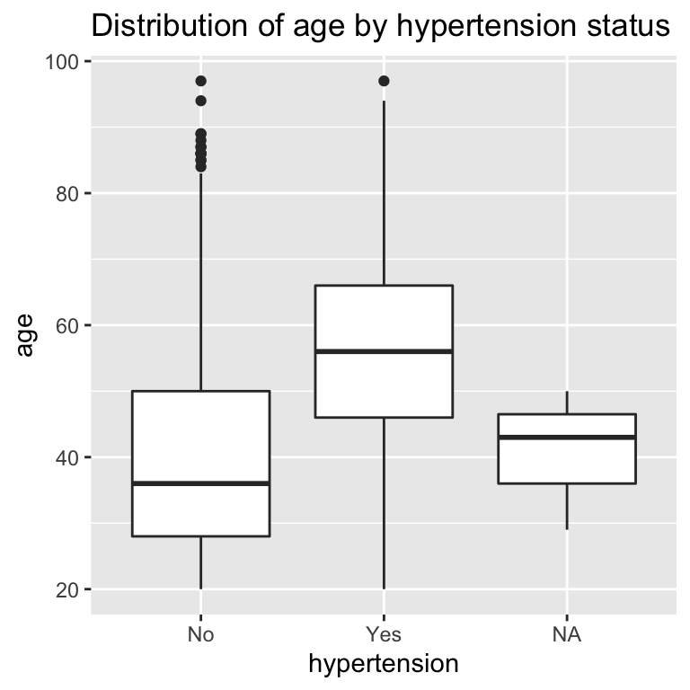

```r
p1 <- hy_df %>%
        ggplot(aes(x = hypertension, y = age)) +
          geom_boxplot() +
          ggtitle('Distribution of age by hypertension status')
p1
```

From this plot, we see that we need to pay attention to the missing values here, since we are getting a boxplot for the missing values. We can remove all rows from our dataset that containing any missing values with the function `drop_na()` in `tidyr` library and store in a new data frame:

```r
hy_p_df <-
  hy_df %>%
  drop_na()

dim(hy_p_df)
```

```
## [1] 1279   13
```

This will drop all rows which still contain missing values. By checking the dimensions of our new data frame, `hy_p_df`, we see that we retain 1279 observations with 13 different variables.

Now we can make the same plot without missing values:

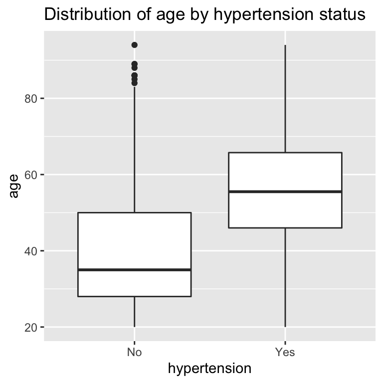

```r
p1 <- hy_p_df %>%
        ggplot(aes(x = hypertension, y = age)) +
          geom_boxplot() +
          ggtitle('Distribution of age by hypertension status')
p1
```

Comparing the medians of these two boxplots, we see that people who are hypertense tend to be older than people who are not, which indicates that age is related to hypertension.

What about a plot for investigating the relationship between `hypertension` and `gender`? Let’s try three different ways to plot the categorical variable `gender` with `hypertension`. We’ll use the function `ggarrange()` in [package `ggpubr`](https://www.rdocumentation.org/packages/ggpubr/versions/0.2) to arrange multiple ggplots on the same page.

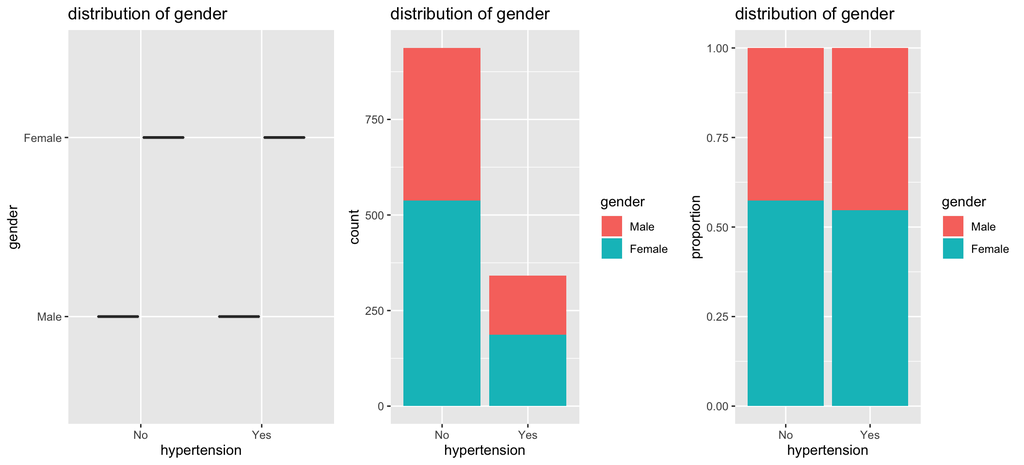

```r
p2 <- hy_p_df %>%
        ggplot(aes(x = hypertension, y=gender)) +
          geom_boxplot() + ggtitle('distribution of gender')
p3 <- hy_p_df %>%
        ggplot(aes(x = hypertension, fill = gender)) +
          geom_bar() + ggtitle('distribution of gender')
p4 <- hy_p_df %>%
        ggplot(aes(x = hypertension, fill = gender)) +
          geom_bar(position = "fill") +
          ggtitle('distribution of gender') +
          ylab('proportion')
ggarrange(p2, p3, p4, ncol=3, nrow=1)
```

The left plot uses `geom_boxplot()` as we did with `age`, but it fails to show the relationship of interest! Boxplots are not what we want for a categorical variable like `gender`, so we need another plotting method.

The middle and right plots use barplots to look at the relationship between `hypertension` and `gender`. This time it works! The middle plot shows the count of males and females for those with and without hypertension. The right plot more clearly shows the proportion of males and females within each hypertension group by using the `position='fill'` option in the `geom_bar()` function. The y-axis in the right plot is proportion rather than count. From this visualization, we see that a slightly lower proportion of the hypertense individuals are female compared to the non-hypertense individuals.

But are these plots really the right ones for our question of interest? Rather than comparing the distribution of gender between the hypertension groups, we really want to see whether there is a difference in hypertension rates between gender groups. To do this, we switch the x-axis and y-axis, to show `hypertension` as a function of `gender`, rather than the other way around.

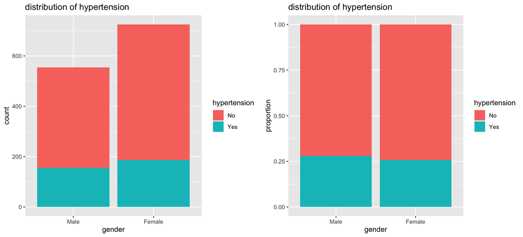

```r
p3b <- hy_p_df %>%
        ggplot(aes(x = gender, fill = hypertension)) +
          geom_bar() + ggtitle('distribution of hypertension')
p4b <- hy_p_df %>%
        ggplot(aes(x = gender, fill = hypertension)) +
          geom_bar(position = "fill") +
          ggtitle('distribution of hypertension') +
          ylab('proportion')
ggarrange(p3b, p4b, ncol=2, nrow=1)
```

Now we can compare the distribution of hypertension between males and females. From this visualization we see that a slightly higher proportion of males than females in our dataset have hypertension.

Next, we apply the same visualization methods on other variables to explore relationships between them.

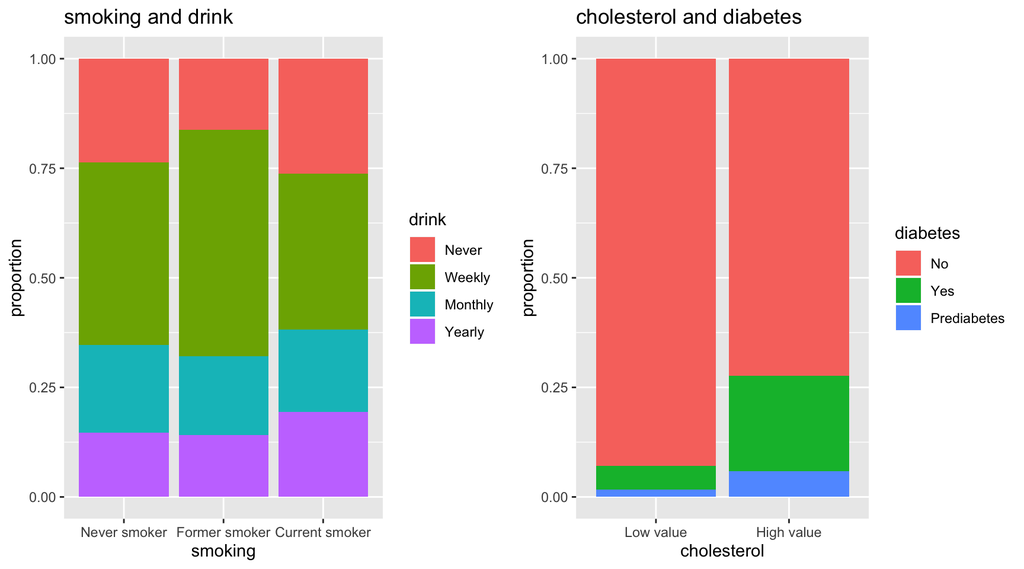

```r
p5 <- hy_p_df %>%
        ggplot(aes(x = smoking, fill = drink)) +
          geom_bar(position = "fill") +
          ggtitle('smoking and drink') + ylab('proportion')
p6 <- hy_p_df %>%
        ggplot(aes(x = cholesterol, fill = diabetes)) +
          geom_bar(position = "fill") +
          ggtitle('cholesterol and diabetes') + ylab('proportion')
ggarrange(p5, p6, ncol=2, nrow=1)
```

From the left plot, we see that there are higher proportions of monthly and yearly drinkers in current smokers, and a higher proportion of weekly drinkers in former smokers. This may imply a potential relationship between smoking and drinking. Additionally, the right plot shows that there is a much higher proportion of diabetes and pre-diabetes in the high cholesterol group compared to the low cholesterol group. Therefore a relationship also appears to exist between these two variables.

What if we want to explore a relationship between more than two variables? Suppose we wanted to look at the relationship between BMI, cholesterol level, and smoking status all at the same time. Since `cholesterol` and `smoking` are both categorical variables, we can divide by the levels of one of these variables, say `smoking`, and then look at plots showing the relationship between the other two variables within each level of `smoking`.

We can do this in `ggplot` by taking the plot statement for two variables (`cholesterol` and `bmi`) and adding a `facet_wrap()` function for the third variable we’re dividing by.

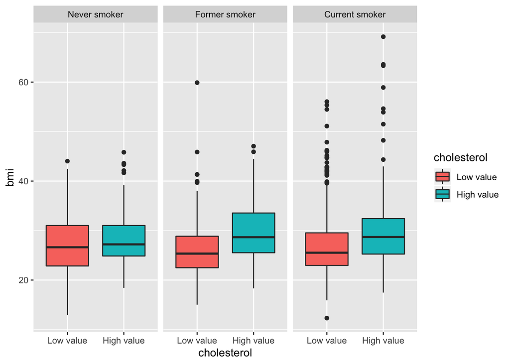

```r
p7 <- hy_p_df %>%
        ggplot(aes(x = cholesterol, y = bmi, fill = cholesterol)) +
          geom_boxplot() + facet_wrap(~ smoking, ncol = 3)
p7
```

The function `facet_wrap(~ smoking, ncol = 3)` uses the faceting capability to produce a plot with three panels (one panel for each smoking category). Within each panel is a boxplot which characterises the distribution of `bmi` for each cholesterol category within that `smoking` category. We see that there is a tendency of higher `bmi` among the higher cholesterol individuals in each smoking category, with the different more pronounced in the former and current smokers.

A through exploratory data analysis is important to get an idea of potential relationships between our variables. The next step is to choose which variables we might include our statistical model in the next section.

# Data analysis

Now that we have spent some time cleaning the data and looking at data visualizations, we want to use a statistical model to address our question of interest about which factors are related to the risk of hypertension.

Which model should we use? Since we are looking at whether or not someone develops hypertension, our outcome variable (`hypertension`) is **binary**. A binary outcome means a logistic regression model is a natural choice. However, think of the nature of our dataset and how it was collected. It is data obtained from a survey, and we have to account for this during the analysis of the data.

In a survey sample, we often end up with “too many” samples in a category, often due to the designed sampling plan. By “too many”, we mean more than would be expected based on the make-up of the population from which we are sampling. For example, we may have a much higher proportion of women in our sample compared to the population and a much lower proportion of men than in the population. This may happen by design if we purposely *oversample* a group that isn’t well represented in the overall population.

To analyze our survey data and infer back to the population, we can use data weighting to account for the mismatch between the population and sample. If we want the data to reflect the whole population, instead of treating each data point equally, we weight the data so that taken together, our sample does reflect the entire community.

To appropriately analyze our data as a survey, we will use the [package `survey`](https://cran.r-project.org/web/packages/survey/survey.pdf), which contains functions for various types of analysis that account for survey design.

## Survey weights

### What are survey weights?

Suppose that we have 25 students (20 male and 5 female) in your biostatistics class, and we want to talk with 5 of them to gauge their understanding of the content in the class. Although the proportion of female students in the population is small, we are very interested in getting their opinion, so we want to be sure to have some female students in our sample. By randomly sampling 5 students from the class, it’s quite possible we could end up with all male students in our sample, and we wouldn’t learn anything about the female perspective in the class.

Consider the extreme case where we are going to require that 4 of the 5 people we sample are female students, to be sure we get good information about the female perspective. We sample 4 of the 5 female students and 1 of the 20 male students. Do we expect this sample to represent the population? Definitely not, since there is a higher proportion of females in the sample than the population. We can correct for this by weighting our samples so that, taken together, they better reflect the composition of the population we want to learn about.

Let’s assume we sampled 4 of the 5 female students and 1 of the 20 male students from our population. To calculate the survey weights, we could use the following formula:

$$Weight = \frac{Proportion~in~population}{Proportion~in~sample}$$
$$w_m=Male~Weight = \frac{20/25}{1/25} = 20$$
$$w_f=Female~Weight = \frac{5/25}{4/25} = 1.25$$
We can interpret these weights by saying that each male student in the sample represents 20 male students in the population and each female student in the sample represents 1.25 female students in the population. Mathematically, we can see this as:

$$1~observed~male* w_m = 20~males$$
and
$$4~observed~females * w_f = 5~females$$

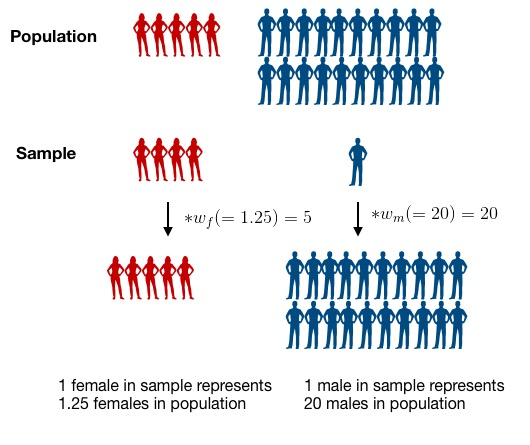

By weighting the observations, we make the sample better represent the population.

For complex survey sampling designs, it can be complicated to calculate the weight for each individual observation. However, for many large survey data sets, such as NHANES, the appropriate weight is calculated by the organization that administers the survey and provided as a variable in the dataset. In our case study, this survey weight is calculated and provided as the `surveyweight` variable and we can simply apply this weight and perform a **survey-weighted logistic regression**.

### Selecting the weights

Because the NYC HANES 2013-2014 data have been collected to address a variety of different questions and using different surveys, the researchers who produced the data have employed a somewhat complex weighting scheme to compensate for unequal probability of selection. Five sets of survey weights have been constructed to correspond to different sets of variables that were collected: CAPI weight, Physical weight, Blood Lab result weight, Urine Lab results weight and Salica Lab results weight. **The determination of the most appropriate weight to use for a specific analysis depends upon the variables selected by the data analyst**.

We will give a table to indicate each variable’s origin stream:

| Variable names | Component |
| --- | --- |
| age | CAPI |
| race | CAPI |
| gender | CAPI |
| diet | CAPI |
| income | CAPI |
| diabetes | CAPI |
| cholesterol | CAPI |
| drink | CAPI |
| smoking | CAPI |
| hypertension | CAPI |
| bmi | EXAM |

When an analysis involves variables from different components of the survey, the analyst should decide whether the outcome is inclusive or exclusive, and then choose certain weights. To learn how to use weights for different purposes, refer to the particular [Analytics Guidelines](http://nychanes.org/wp-content/uploads/sites/6/2015/11/ANALYTIC-GUIDELINES-2016_V2.pdf) for the survey.

In our case, we choose EXAM weight since our analysis is exclusive. Do you remember we have moved all of the missing value? Now our dataset is limited to those who receive physical exam test, which means all of our survey participants have a value for the `EXAM_WT` variable. We’ve select this variable and renamed it as `surveyweight` in the earlier data cleaning part of this analysis.

## Finite population correction factor

There is one more technical detail that we need to consider when using survey data. Many methods for analysis of survey data make the assumption that **samples were collected using sampling with replacement**, i.e., any time a new participant is drawn, each member in the population has an equal chance of being sampled, even if they have already been sampled. This is not usually how surveys are actually carried out, so an adjustment may be necessary to reflect this difference. This adjustment is called the **finite population correction factor** and it is defined as:

$$FPC = (\frac{N-n}{N-1})^{\frac{1}{2}}$$

- `N` = population size
- `n` = sample size

In the case when the assumption above is violated (e.g. if you are sampling a sufficiently large proportion of the population), then you might sample the same persion twice. The finite population correction (FPC) is used to reduce the variance when a substantial fraction of the total population of interest has been sampled. We can find the value of `N` and `n` for our survey from the [Analytics Guidelines](http://nychanes.org/wp-content/uploads/sites/6/2015/11/ANALYTIC-GUIDELINES-2016_V2.pdf). Next let’s calculate the FPC as below:

```r
N <-  6825749
n <- dim(hy_df)[1]
((N-n)/(N-1))^0.5
```

```
## [1] 1
```

The FPC of our data set is very close to 1 since our sample is quite small compared to the size of the population, and we could simply ignore the FPC. But technically, since the data were collected through sampling without replacement, it is more appropriate to use it.

## Specify the survey design

We now need to figure out how to specify the survey design and incorporate the sampling weights in our modeling steps. To help us do this, we use the function `svydesign()` in [package `survey`](https://cran.r-project.org/web/packages/survey/survey.pdf). This function combines a data frame and all the design information needed to specify a survey design. Here is the list of options provided in this function:

- `ids`: Formula used to specify the cluster sampling design. *Cluster sampling* is a multi-stage sampling design where the total population is divided into several clusters and a simple random sample of clusters are selected. Then a sample is taken from the elements of each selected cluster. Use `~0` or `~1` as the formula when there are no clusters.
- `data`: Data frame (or database table name) containing the variables for analysis look up variables in the formula arguments.
- `weights`: Dormula or vector specifying the sampling weights.
- `fpc`: Finite population correction, `~rep(N,n)` generates a vector of length n where each entry is N (the population size). Default value is 1. The use of fpc indicates a sample without replacement, otherwise the default is a sample with replacement.
- `strata`: Specification for stratified sampling. *Stratified sampling* is a sampling design which divides members of the population into homogeneous subgroups and then samples independently in these subpopulations. It is advantageous when subpopulations within an overall population vary.

In our situation, we don’t have any clusters or stratified sampling to specify, we just need to include the appropriate survey weights provided with the data. We will not include a FPC, since our FPC was approximately 1.

Here’s how we specify the design relative to our dataset:

```r
hypertension_design <- svydesign(
  id = ~1,
  #fpc = ~rep(N,n),
   weights = ~hy_df$surveyweight,
  data = hy_df
)
```

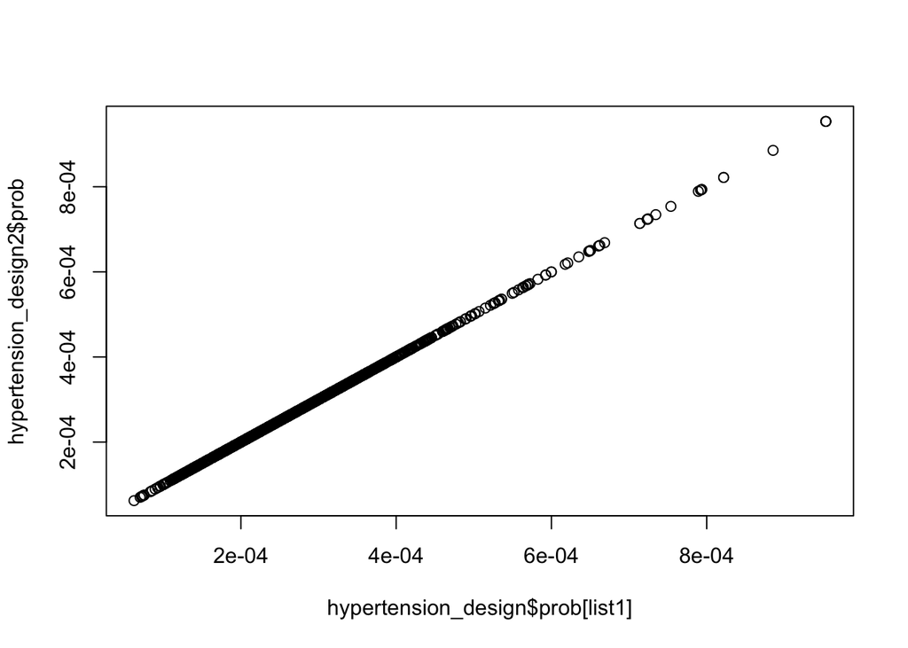

```r
#this part is used to compare the svy-design with and without missing value
hypertension_design2 <- svydesign(
  id = ~1,
   weights = ~hy_p_df$surveyweight,
  data = hy_p_df
)

v2 <- hypertension_design2$variables[,1]
v1 <- hypertension_design$variables

list1 <- as.numeric(row.names(v1[v1$id %in% v2,]))
plot(hypertension_design$prob[list1],hypertension_design2$prob)
```

The arguments are interpreted as the following:

- `ids = ~1` means there is no cluster sampling
- `data = hy_df` tells `svydesign` where to find the variables for analysis
- `weights= ~hy_df$surveyweight` tells it where to find the weight in our data frame

We can use `summary()` to show the results:

```r
summary(hypertension_design)
```

```
## Independent Sampling design (with replacement)
## svydesign(id = ~1, weights = ~hy_df$surveyweight, data = hy_df)
## Probabilities:
##    Min. 1st Qu.  Median    Mean 3rd Qu.    Max.
## 0.00006 0.00020 0.00027     Inf 0.00035     Inf
## Data variables:
##  [1] "id"           "age"          "race"         "gender"       "diet"
##  [6] "income"       "diabetes"     "bmi"          "cholesterol"  "drink"
## [11] "smoking"      "hypertension" "surveyweight"
```

“Independent sampling design” means our sampling design is a simple random sample (SRS). By setting other parameters it is possible to specify different kinds of designs, such as stratified sampling, cluster sampling, or other multi-stage designs.

## Calculate survey-weighted summary statistics

Once we have created our `svydesign` object, we can use the convenient `svy*` functions to calculate summary statistics that account for survey design features.

To calculate the mean and its standard error, use the function `svymean()`. The `svymean()` function calculates a weighted estimate for the mean by weighting each observation with it’s sampling weight. We can compare this result to ignoring the survey weights using the `mean()` and `std.error()` functions in base R.

Here we look at both the weighted and un-weighted mean BMI:

```r
svymean(~bmi, hypertension_design)
```

```
##     mean SE
## bmi   NA NA
```

```r
mean(hy_df$bmi)
```

```
## [1] NA
```

```r
std.error(hy_df$bmi)
```

```
## [1] 0.17
```

To calculate a survey-weighted confidence interval for mean BMI value, we use the function `confint()` directly on the `svymean()` function:

```r
confint(svymean(~bmi, hypertension_design))
```

```
##     2.5 % 97.5 %
## bmi   NaN    NaN
```

Statistics for subgroups are also easy to calculate with the function `svyby()`. Here we look at mean BMI within groups defined by diet quality.

```r
svyby(~bmi, by=~diet, design = hypertension_design,
      FUN = svymean)
```

```
##                diet bmi   se
## Poor           Poor  30 0.83
## Fair           Fair  NA  NaN
## Good           Good  NA  NaN
## Very good Very good  NA  NaN
## Excellent Excellent  NA  NaN
```

If we are particularly interested in one subgroup of individuals, we can use the `subset()` to define a design for our subgroup of interest. For example, if we are only interested in learning about the female population:

```r
h_design_female <- subset(hypertension_design,gender=="Female")
svymean(~bmi, h_design_female)
```

```
##     mean SE
## bmi   NA NA
```

Note that if we are limiting our analysis to a subgroup of the data, we **must** use the subset command to define a new survey design that relates to this new subpopulation. This is because the survey weights need to be updated to reflect how the data represents this new population. The `subset` command will appropriately update the survey weights so the analysis reflects the survey design of the subsetted data. We **cannot** simply use a subset of the data with the original survey design.

## Survey-weighted logistic regression

### Fit a simple model

Logistic regression is widely used to when the response variable is binary. The standard logistic regression equation can be written as:

$logit(p)= log(\frac{p}{1-p})=X^{T}\beta$, where $p=P(Y=1)=E(Y)$

As we mentioned above, our data comes from a survey design so we need to take survey weights into account in our analysis. We can do that with a survey-weighted logistic regression using the `svyglm()` function from the `survey` package.

The `svyglm()` function works similarly to using `glm()` to fit a standard logistic regression model. The only difference is that instead of using the original data set in the `data` argument within `glm()`, we instead input the survey design object from `svydesign()` in the `design` argument in `svyglm()`.

Now we can fit our survey-weighted logistic regression model and look at the summarized output. We will start with a simple model by choosing one variable, `smoking`, as a predictor:

```r
g <- svyglm(hypertension ~ smoking,
    family = binomial(link = 'logit'), design = hypertension_design)
```

```
## Warning in eval(family$initialize): non-integer #successes in a binomial glm!
```

```r
summary(g)
```

```
##
## Call:
## svyglm(formula = hypertension ~ smoking, design = hypertension_design,
##     family = binomial(link = "logit"))
##
## Survey design:
## svydesign(id = ~1, weights = ~hy_df$surveyweight, data = hy_df)
##
## Coefficients:
##                       Estimate Std. Error t value Pr(>|t|)
## (Intercept)             -0.492      0.130   -3.77  0.00017 ***
## smokingFormer smoker    -0.605      0.201   -3.02  0.00258 **
## smokingCurrent smoker   -0.515      0.155   -3.31  0.00094 ***
## ---
## Signif. codes:  0 '***' 0.001 '**' 0.01 '*' 0.05 '.' 0.1 ' ' 1
##
## (Dispersion parameter for binomial family taken to be 1)
##
## Number of Fisher Scoring iterations: 4
```

If we allow `warning = TRUE`, a warning would appear as “non-integer #successes in a binomial glm!”. But everything is right here! `glm` and `svyglm` are just picky. They warn if they detect that the no. of trials or successes is non-integral, but they go ahead and fit the model anyway. If you want to suppress the warning (and you’re sure it’s not a problem), use `family=quasibinomial()` instead.

```r
g0 <- svyglm(hypertension ~ smoking,
    family = quasibinomial(link = 'logit'), design = hypertension_design)
```

[output not shown]

```
## Warning in summary.glm(glm.object): observations with zero weight not used for
## calculating dispersion
```

```r
summary(g0)
```

```
##
## Call:
## svyglm(formula = hypertension ~ smoking, design = hypertension_design,
##     family = quasibinomial(link = "logit"))
##
## Survey design:
## svydesign(id = ~1, weights = ~hy_df$surveyweight, data = hy_df)
##
## Coefficients:
##                       Estimate Std. Error t value Pr(>|t|)
## (Intercept)             -0.492      0.130   -3.77  0.00017 ***
## smokingFormer smoker    -0.605      0.201   -3.02  0.00258 **
## smokingCurrent smoker   -0.515      0.155   -3.31  0.00094 ***
## ---
## Signif. codes:  0 '***' 0.001 '**' 0.01 '*' 0.05 '.' 0.1 ' ' 1
##
## (Dispersion parameter for quasibinomial family taken to be 1)
##
## Number of Fisher Scoring iterations: 4
```

The `tidy()` function in the `broom` package can provide a dataframe representation of the model’s output. Now we can see the model output as a nice dataframe!

```r
g_res <- tidy(g0)
g_res
```

```
## # A tibble: 3 x 5
##   term                  estimate std.error statistic  p.value
##   <chr>                    <dbl>     <dbl>     <dbl>    <dbl>
## 1 (Intercept)             -0.492     0.130     -3.77 0.000167
## 2 smokingFormer smoker    -0.605     0.201     -3.02 0.00258
## 3 smokingCurrent smoker   -0.515     0.155     -3.31 0.000940
```

As in standard logistic regression using `glm()`, we see the coefficient estimate, standard error, test statistic, and p-value for each term in our model. We can still get survey-weighted confidence intervals with the `confint()` function:

```r
confint(g0)
```

```
##                       2.5 % 97.5 %
## (Intercept)           -0.75  -0.24
## smokingFormer smoker  -1.00  -0.21
## smokingCurrent smoker -0.82  -0.21
```

```r
exp(g0$coefficients)
```

```
##           (Intercept)  smokingFormer smoker smokingCurrent smoker
##                  0.61                  0.55                  0.60
```

### Fit a full model

Now we can fit a full model that includes all of our variables of interest:

```r
g1 <- svyglm(hypertension ~
               age + race + gender + diet + income +
               diabetes + bmi + cholesterol + drink + smoking,
             family = binomial(link = 'logit'),
             design = hypertension_design)
g1_res <- tidy(g1)
g1_res %>% as.data.frame()
```

```
##                          term estimate std.error statistic p.value
## 1                 (Intercept)  -4.9041    0.6728    -7.289 5.5e-13
## 2                         age   0.0404    0.0057     7.066 2.6e-12
## 3  raceBlack/African American   0.8834    0.2185     4.042 5.6e-05
## 4   raceIndian /Alaska Native  -0.7059    0.7446    -0.948 3.4e-01
## 5        racePacific Islander   2.1259    0.8714     2.440 1.5e-02
## 6                   raceAsian   0.4078    0.2664     1.530 1.3e-01
## 7              raceOther Race   0.2616    0.2802     0.934 3.5e-01
## 8                genderFemale  -0.2856    0.1810    -1.578 1.1e-01
## 9                    dietFair   0.1001    0.3442     0.291 7.7e-01
## 10                   dietGood   0.1694    0.3345     0.507 6.1e-01
## 11              dietVery good  -0.3000    0.3605    -0.832 4.1e-01
## 12              dietExcellent  -0.1580    0.4173    -0.379 7.0e-01
## 13    income$20,000 - $39,999  -0.4952    0.2177    -2.275 2.3e-02
## 14    income$40,000 - $59,999  -0.7021    0.3044    -2.307 2.1e-02
## 15    income$60,000 - $79,999  -0.3714    0.2886    -1.287 2.0e-01
## 16    income$80,000 - $99,999  -0.8390    0.4652    -1.803 7.2e-02
## 17     income$100,000 or more  -0.6605    0.2737    -2.413 1.6e-02
## 18                diabetesYes   0.8380    0.2553     3.282 1.1e-03
## 19        diabetesPrediabetes   0.1695    0.3914     0.433 6.7e-01
## 20                        bmi   0.0727    0.0136     5.353 1.0e-07
## 21      cholesterolHigh value   0.8042    0.1768     4.549 5.9e-06
## 22                drinkWeekly   0.0055    0.2389     0.023 9.8e-01
## 23               drinkMonthly  -0.2895    0.2612    -1.108 2.7e-01
## 24                drinkYearly  -0.0180    0.2540    -0.071 9.4e-01
## 25       smokingFormer smoker  -0.5073    0.2704    -1.876 6.1e-02
## 26      smokingCurrent smoker  -0.2195    0.2226    -0.986 3.2e-01
```

One interesting thing is that both the coefficients and p-values for the `smoking` variables are different than in our simple model. Why did this happen? Remember that with other variables in the model, our interpretation of the coefficients for smoking changes. We now have to interpret them as describing the relationship between smoking and hypertension *while holding the other variables in the model constant.* If the other variables in the model are also related to `smoking`, then the relationship between smoking and hypertension may be difference once we account for the other variables compared to the relationship of smoking on it’s own.

```r
exp(g1$coefficients)
```

```
##                (Intercept)                        age
##                     0.0074                     1.0412
## raceBlack/African American  raceIndian /Alaska Native
##                     2.4190                     0.4937
##       racePacific Islander                  raceAsian
##                     8.3801                     1.5034
##             raceOther Race               genderFemale
##                     1.2991                     0.7515
##                   dietFair                   dietGood
##                     1.1053                     1.1847
##              dietVery good              dietExcellent
##                     0.7409                     0.8538
##    income$20,000 - $39,999    income$40,000 - $59,999
##                     0.6094                     0.4956
##    income$60,000 - $79,999    income$80,000 - $99,999
##                     0.6898                     0.4321
##     income$100,000 or more                diabetesYes
##                     0.5166                     2.3117
##        diabetesPrediabetes                        bmi
##                     1.1848                     1.0755
##      cholesterolHigh value                drinkWeekly
##                     2.2349                     1.0055
##               drinkMonthly                drinkYearly
##                     0.7487                     0.9821
##       smokingFormer smoker      smokingCurrent smoker
##                     0.6021                     0.8030
```

### Model selection

```r
g2 <- svyglm(hypertension ~
        age + bmi + cholesterol + diabetes + gender +
        smoking + diet,
        family = binomial(link = 'logit'),
        design = hypertension_design)
```

Using this model output, we would like to further examine which covariates have the larger influence on hypertension. To do this, we compare their effect sizes in the plot below.

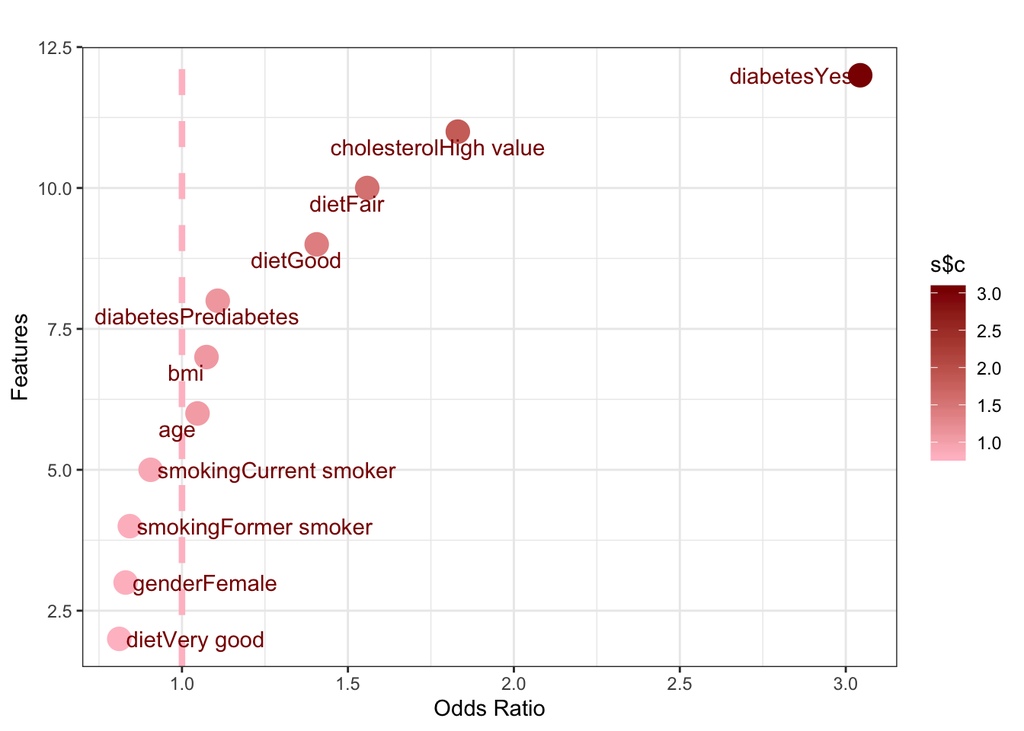

```r
s <- data.frame('c' = exp(g2$coefficients[2:12]),
                'n' = names(g2$coefficients)[2:12])
s <- s[order(s$c),]
l = seq(from = 2, to = 12, by = 1)

plt<- ggplot(s, aes(x = l, y = c,col = s$c)) +
  geom_point(size = 5)  +
  scale_colour_gradient(low ='pink', high = 'darkred')+
  geom_hline(yintercept = 1,col = 'pink',size = 1.5, linetype = 2)+
  theme_bw() + theme(plot.title = element_text(hjust = 2, vjust = -2))+
  geom_text_repel(aes(y = c,label = n), col = 'darkred')+
  ggtitle("Effect on Hypertension") +
  ylab("Odds Ratio") +
  xlab("Features")+
  coord_flip()

plt
```

Here we plot the exponentiated coefficients, or odds ratios, for each term in the model. If the odds ratio is larger than 1, then the term is associated with an increased risk of hypertension. If the odds ratio is less than 1, then the term is associated with a descreased risk of hypertention. Moreover, a larger absolute value indicates a larger effect on hypertension. Remember that the categorical variables are all with respect to the reference category.

## Compare to logistic regression

What would happen if we didn’t know to use survey weighting in our analysis and instead simply used standard logistic regression? We can compare the results of using `glm()` to using `svyglm()` to analyze the data.

```r
g_glm <- glm(hypertension ~ smoking,
          family = binomial(link = 'logit'),
          data = hy_df)


g_glm_res <- tidy(g_glm)
g_glm_res
```

```
## # A tibble: 3 x 5
##   term                  estimate std.error statistic     p.value
##   <chr>                    <dbl>     <dbl>     <dbl>       <dbl>
## 1 (Intercept)             -0.600     0.118     -5.10 0.000000342
## 2 smokingFormer smoker    -0.475     0.181     -2.63 0.00861
## 3 smokingCurrent smoker   -0.490     0.140     -3.51 0.000455
```

We see that the values of the smoking coefficients are different. In order to compare them to the survey results easily, we can merge these two outputs into a single table. Only coefficients and standard errors are kept for simplicity.

The `merge()` function offer an efficient way to merge two data frames by common columns or row names.

```r
merge(g_res[1:3], g_glm_res[1:3], by = 'term')
```

```
##                    term estimate.x std.error.x estimate.y std.error.y
## 1           (Intercept)      -0.49        0.13      -0.60        0.12
## 2 smokingCurrent smoker      -0.51        0.16      -0.49        0.14
## 3  smokingFormer smoker      -0.61        0.20      -0.48        0.18
```

The first two columns here refer to the survey-weighted model and the last two columns show the standard logistic regression results. We see that the coefficient estimates are different between the two models and that the standard errors calculated by the survey-weighted model are slightly wider than those calculated in the standard case. Without survey weighting, our standard errors are smaller than they should be when taking into account the survey design.

Now let’s compare the full model designed by these two methods.

```r
g3 <- glm(hypertension ~
            age + bmi + cholesterol + diabetes + gender +
            smoking + diet,
          family = binomial(link = 'logit'),
          data = hy_df)
```

For this larger model, we would like to compare the two methods visually rather than show them in a long table.

## Visualization of model outputs

We will repeat the same procedure we did for the simple model, construct the confidence intervals manually, and then save the information in one dataframe.

```r
g2_res <- tidy(g2) %>%
  mutate(
    low = estimate - 1.96 * std.error,
    high = estimate + 1.96 * std.error,
    len = high-low,
    method = 'svyglm'
  )

g3_res <- tidy(g3) %>%
  mutate(
    low = estimate - 1.96 * std.error,
    high = estimate + 1.96 * std.error,
    len = high-low,
    method = 'glm'
  )


res <- rbind(g2_res, g3_res)
#reorder the dataframe based on length of confidence interval
res <- res[order(res$len),][1:24,]
```

The `mutate()` function is used here to add new variables or replace existing columns in the dataframe. The label names are a default setting, but to make it more readable, we can specify the label names.

```r
res$term <- c('age' ,'age' ,'bmi','bmi',
'gender','cholesterol','gender',
'cholesterol','current smoker',
'current smoker','diabetes',
 'former smoker','diabetes',
'former smoker', 'good diet','fair diet',
'very good diet','good diet','fair diet',
'very good diet','excellent diet',
'prediabetes','excellent diet',
'prediabetes')
```

Now, let’s plot the confidence intervals using `ggplot`.

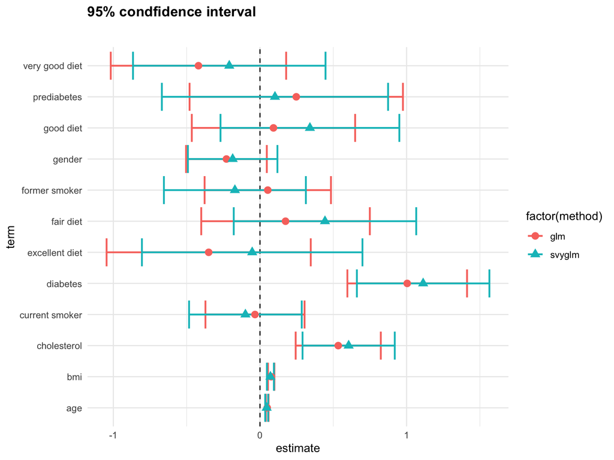

```r
ggplot(res, aes(x = estimate, y = term),
     group_by(res2$method)) +
     geom_vline(xintercept = 0, linetype = "dashed") +
     geom_errorbarh(aes(estimate, term, xmin = low,
     xmax = high, color = factor(method),width = 0.3), size = 0.8)+
     geom_point(aes(color = factor(method),
                    shape = factor(method)),size = 3)+
     theme(axis.title.x = element_blank(),
     axis.title.y = element_blank()) +
    ggtitle(expression(atop(bold("95% condfidence interval"))))+
   theme_minimal()
```

```r
ggsave("data/Finalplot.png", plot = last_plot(), device = "png")
```

We see that `diabetes`, `smoking` and `diet` have larger differences in confidence intervals comparing the standard glm to the survey-weighted glm results, while `age`, `bmi`, `cholesterol` and `gender` have only small differences. We also see that, in general, the confidence intervals from `ci_svyglm` are larger than those from `ci_glm`. So we would not get the “correct” results if we failed to take into account the survey weighting in our analysis.

# Summary of results

In this study, we investigated risk factors that may contribute to hypertension and used survey-weighted logistic regression to handle a binary response variable while accounting for survey weights. The use of survey weights is the main focus of this case study. Thus, we apply two approaches (with and without survey weights) to compare their results: one is standard logistic regression and the other is survey weight logistic regression.

In the future, we can make more efforts on applied survey methods and decide whether there exist better approaches, such as stratified sample.